# Julia for GIS

Why Julia for geospatial work?

Rafael Schouten

NINA

2024-04-12

# What is Julia?

- A relatively new language for scientific computing
- Designed for math and science, and performance

[figure not shown]

# How is Julia both dynamic fast?

- Compiled with LLVM like Rust and some C
- So it can be as fast or faster than C
- But it can compile more code at run-time, as you use it
- So it “feels” interpreted, like R and Python
- The language was designed to make this possible

# Some syntax

```julia
x = 1
x * 2
```

```
2
```

## Vectors and Arrays (lists)

```julia
V = [10, 20, 30, 40, 50]
V[5]
```

```
50
```

Broadcasts (like apply/lapply) :

```julia
V .* 2
```

```
5-element Vector{Int64}:
  20
  40
  60
  80
 100
```

## Functions

```julia
f(x) = 2x
f(4)
```

```
8
```

Broadcast functions over arrays:

```julia
f.([1, 2, 3])
```

```
3-element Vector{Int64}:
 2
 4
 6
```

Multiline functions

```julia
function add(x, y)
    x + y
end

add(2, 3)
```

```
5
```

```julia
add(2.0, 3)
```

```
5.0
```

```julia
add([1, 2, 3], [4, 5, 6])
```

```
3-element Vector{Int64}:
 5
 7
 9
```

# Types

Julia doesn’t hide number types from you:

```julia
x = 1.0
typeof(x * 2)
```

```
Float64
```

```julia
x = 1
typeof(x * 2)
```

```
Int64
```

# Why not to use Julia?

- Its young
- Much smaller user-base
- There are not a million answered questions on the internet already
- You will need to ask questions on discourse and github yourself!
- But you can normally just talk to developers directly

# Julia for GIS

JuliaGeo

[Julia Geocompx book](https://jl.geocompx.org/)

## Common interface packages:

- GeoInterface.jl: common interface for geospatial objects
- DiskArrays.jl: lazy loading and out-of-core operations on large raster data
- CommonDataModel.jl: CF standards for loading NetCDF, Zarr and Grib files
- Tables.jl: unites all tablular/dataframe data

# GeometryOps.jl

- spatial operations on any GeoInterface.jl compatible geometry data
- very new!!

# Example op: `simplify`

```julia
import GeometryOps as GO, GeoInterface as GI
using NaturalEarth, CairoMakie, DataFrames
countries = naturalearth("ne_10m_admin_0_countries") |> DataFrame
simplified = GO.simplify(countries; ratio=0.01)
australia = subset(simplified, :NAME => ByRow(==("Australia")))
p = Makie.plot(australia.geometry; axis=(; aspect=DataAspect()))
```

[figure not shown]

# GeoDataFrames.jl

Load vector datasets as a DataFrames.jl dataframe, using gdal and/or native julia file loaders.

```julia
import GeoDataFrames as GDF
df = GDF.read("my_shapefile.shp")
```

## There are also wrappers for common GIS libraries:

- LibGEOS.jl for geos
- GDAL.jl and ArchGDAL.jl for gdal
- Proj.jl for proj projections
- etc.

## And native julia IO packages

- Shapefile.jl
- GeoJSON.jl
- GeoParquet.jl
- etc…

# Rasters.jl

Multidimensional raster data and operations.

Somewhere between Rs `raster` and pythons `XArray`

## Load a file

```julia
using Rasters, RasterDataSources, ArchGDAL, Dates
filename = getraster(WorldClim{Future{BioClim,CMIP6,MRI_ESM2_0,SSP126}}, 5;
    date=Date(2050), res = "10m"
)
rast = Raster(filename; lazy=true)
```

[output not shown]

```
╭────────────────────────────────╮
│ 2160×1080×19 Raster{Float32,3} │
├────────────────────────────────┴─────────────────────────────────────── dims ┐
  ↓ X    Projected{Float64} LinRange{Float64}(-180.0, 179.83333333333331, 2160) ForwardOrdered Regular Intervals{Start},
  → Y    Projected{Float64} LinRange{Float64}(89.83333333333333, -90.0, 1080) ReverseOrdered Regular Intervals{Start},
  ↗ Band Categorical{String} [bio01, bio02, …, bio18, bio19] Unordered
├──────────────────────────────────────────────────────────────────── metadata ┤
  Metadata{Rasters.GDALsource} of Dict{String, Any} with 4 entries:
  "units"    => ""
  "offset"   => 0.0
  "filepath" => "./WorldClim/Future/BioClim/ssp126/MRI-ESM2-0/wc2.1_10m_bioc_MR…
  "scale"    => 1.0
├────────────────────────────────────────────────────────────────────── raster ┤
  extent: Extent(X = (-180.0, 179.99999999999997), Y = (-90.0, 90.0), Band = (nothing, nothing))
  missingval: NaN32
  crs: GEOGCS["WGS 84",DATUM["WGS_1984",SPHEROID["WGS 84",6378137,298.257223563,AUTHORITY["EPSG","7030"]],AUTHORITY["EPSG","6326"]],PRIMEM["Greenwich",0,AUTHORITY["EPSG","8901"]],UNIT["degree",0.0174532925199433,AUTHORITY["EPSG","9122"]],AXIS["Latitude",NORTH],AXIS["Longitude",EAST],AUTHORITY["EPSG"…
  filename:
└──────────────────────────────────────────────────────────────────────────────┘
```

A Raster follows julias array interface:

```julia
rast isa AbstractArray
```

```
true
```

So most array operations work on rasters

```julia
rast10 = rast .* 10
rast10
```

```
╭────────────────────────────────╮
│ 2160×1080×19 Raster{Float32,3} │
├────────────────────────────────┴─────────────────────────────────────── dims ┐
  ↓ X    Projected{Float64} LinRange{Float64}(-180.0, 179.83333333333331, 2160) ForwardOrdered Regular Intervals{Start},
  → Y    Projected{Float64} LinRange{Float64}(89.83333333333333, -90.0, 1080) ReverseOrdered Regular Intervals{Start},
  ↗ Band Categorical{String} [bio01, bio02, …, bio18, bio19] Unordered
├──────────────────────────────────────────────────────────────────── metadata ┤
  Metadata{Rasters.GDALsource} of Dict{String, Any} with 4 entries:
  "units"    => ""
  "offset"   => 0.0
  "filepath" => "./WorldClim/Future/BioClim/ssp126/MRI-ESM2-0/wc2.1_10m_bioc_MR…
  "scale"    => 1.0
├────────────────────────────────────────────────────────────────────── raster ┤
  extent: Extent(X = (-180.0, 179.99999999999997), Y = (-90.0, 90.0), Band = (nothing, nothing))
  missingval: NaN32
  crs: GEOGCS["WGS 84",DATUM["WGS_1984",SPHEROID["WGS 84",6378137,298.257223563,AUTHORITY["EPSG","7030"]],AUTHORITY["EPSG","6326"]],PRIMEM["Greenwich",0,AUTHORITY["EPSG","8901"]],UNIT["degree",0.0174532925199433,AUTHORITY["EPSG","9122"]],AXIS["Latitude",NORTH],AXIS["Longitude",EAST],AUTHORITY["EPSG"…
  filename:
└──────────────────────────────────────────────────────────────────────────────┘
```

Reads from disk/network on `getindex`:

```julia
rast10[X=100 .. 135, Y=20 .. 40, Band=1]
```

```
╭───────────────────────────╮
│ 209×120 Raster{Float32,2} │
├───────────────────────────┴──────────────────────────────────────────── dims ┐
  ↓ X Projected{Float64} LinRange{Float64}(100.16666666666664, 134.8333333333333, 209) ForwardOrdered Regular Intervals{Start},
  → Y Projected{Float64} LinRange{Float64}(39.83333333333332, 20.0, 120) ReverseOrdered Regular Intervals{Start}
├──────────────────────────────────────────────────────────────────── metadata ┤
  Metadata{Rasters.GDALsource} of Dict{String, Any} with 4 entries:
  "units"    => ""
  "offset"   => 0.0
  "filepath" => "./WorldClim/Future/BioClim/ssp126/MRI-ESM2-0/wc2.1_10m_bioc_MR…
  "scale"    => 1.0
├────────────────────────────────────────────────────────────────────── raster ┤
  extent: Extent(X = (100.16666666666664, 134.99999999999994), Y = (20.0, 39.999999999999986))
  missingval: NaN32
  crs: GEOGCS["WGS 84",DATUM["WGS_1984",SPHEROID["WGS 84",6378137,298.257223563,AUTHORITY["EPSG","7030"]],AUTHORITY["EPSG","6326"]],PRIMEM["Greenwich",0,AUTHORITY["EPSG","8901"]],UNIT["degree",0.0174532925199433,AUTHORITY["EPSG","9122"]],AXIS["Latitude",NORTH],AXIS["Longitude",EAST],AUTHORITY["EPSG"…
└──────────────────────────────────────────────────────────────────────────────┘
   ↓ →     39.8333   39.6667   39.5  …   20.5   20.3333   20.1667   20.0
 100.167  100.0     100.0      95.0     244.0  259.0     260.0     266.0
   ⋮                                 ⋱                               ⋮
 134.833  NaN       NaN       NaN       NaN    NaN       NaN       NaN
```

# Plotting

## Makie.jl

[output not shown]

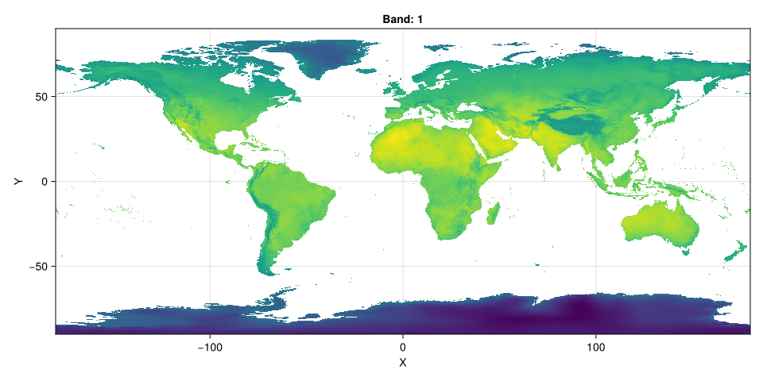

```julia
using CairoMakie
bioclim5 = Raster(WorldClim{BioClim}, 5)
Makie.plot(bioclim5)
```

## GeoMakie.jl

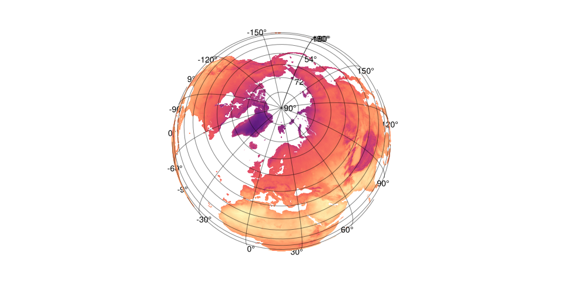

```julia
using GeoMakie, DataFrames
fig = Figure();
ga = GeoAxis(fig[1, 1]; dest="+proj=ortho +lon_0=19 +lat_0=72")
Makie.heatmap!(ga, bioclim5; colormap=:magma)
fig
```